# Training Convolutional Neural Network for Leaf Trait Prediction

2024-10-14

Authors: Methun George, Dr. Steffen Neumann and Pablo Castro Sánchez-Bermejo

The vignette is inspired from “Tree and mycorrhizal fungal diversity drive intraspecific and intraindividual trait variation in temperate forests: Evidence from a tree diversity experiment” (https://doi.org/10.1111/1365-2435.14549) conducted by Pablo Castro Sánchez-Bermejo. In this study, we focus on predicting five leaf traits such as Specific Leaf Area (SLA), Leaf Dry Matter Content (LDMC), Carbon Content, Phosphorus Content, and Carbon-to-Nitrogen Ratio (C:N) using a Convolutional Neural Network (CNN).

```r
#Loading all the required libraries

library(readxl) # For reading the data
library(dplyr) # For data management
library(tidyr) # For data management
library(tfruns) # For training convolutional neural networks
library(keras3) # For training convolutional neural networks
library(plantspec) # For managing spectral data
library(ggplot2) # For plotting predicted versus measured data
library(ggExtra) # For plotting predicted versus measured data
library(sfsmisc) # For data augmentation
library(gridExtra) # For plot visualization
library(plotly) # For interactive plots
library(SummarizedExperiment) # For better data handling
```

The libraries needed for data processing, structuring, and modeling are loaded above. The next section, will import the spectral and trait datasets from the study( “https://besjournals.onlinelibrary.wiley.com/doi/full/10.1111/1365-2435.14549” ).

# Datasets

```r
### Datasets ####
plantspec.spectra <- read_excel("/Users/methungeorge/Desktop/IPB/pablo/dataset_20231010.xlsx", sheet = "Calibration set spectra") # Spectra calibration set
plantspec.data <- read_excel("/Users/methungeorge/Desktop/IPB/pablo/dataset_20231010.xlsx", sheet = "Calibration set traits") # Trait calibration set
plantspec.data$SLA <- as.numeric(plantspec.data$SLA)
plantspec.data$LDMC <- as.numeric(plantspec.data$LDMC)
plantspec.data$CN <- as.numeric(plantspec.data$CN)
plantspec.data$C <- as.numeric(plantspec.data$C)
plantspec.data$P <- as.numeric(plantspec.data$P)

cbind(plantspec.spectra$Spectral.file.name, plantspec.data$File_name) # Checking correlation between both sets
```

# SLA

After importing the datasets, the next step involves processing and cleaning the SLA data, which is a trait in the dataset. This includes removing outliers, handling missing values, and preparing the dataset for analysis. The SLA distribution will be examined to check for normality, followed by splitting the data into training and test sets.

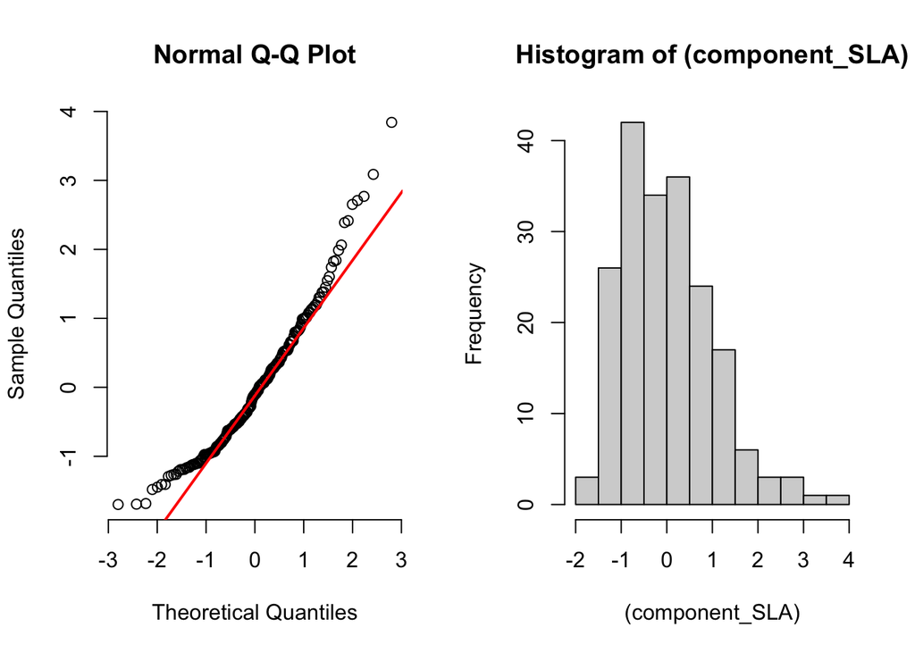

```r
#############
#### SLA ####
#############

# Removing outlayer from the samples
plantspec.data[which(is.na(plantspec.data$SLA)),]
input <- as.matrix(plantspec.spectra[, -1])
input <- input[-which(is.na(plantspec.data$SLA)),]
plantspec.data.sla <- plantspec.data[!is.na(plantspec.data$SLA),]
input <- input[-which(plantspec.data$Tree == "70_Ti3"),]
plantspec.data.sla <- subset(plantspec.data.sla, Tree != "70_Ti3")

# Studying the distribution of the values for SLA
component_SLA <- plantspec.data.sla$SLA
component_SLA <- scale(component_SLA)
par(mfcol = c(1, 2))
qqnorm((component_SLA), pch = 1, frame = FALSE) # Checking normality of the variable
qqline((component_SLA), col = "red", lwd = 2)
hist((component_SLA)) # Checking distribution of the variable
```

```r
#### Train-test split ####
# We split our samples into train and test set (0.7-0.3) by using
# a PCA of the spectra
dimnames(input) = NULL
set.seed(0)
training_set <- !(subdivideDataset(spectra = input,
                                   component = component_SLA,
                                   method = "PCAKS", p = 0.3,
                                   type = "validation"))
```

### SNV Transformation

```r
#### Feature Engineering ####

# 1) Standard Norval Variate (SNV)


input <- data.frame(input)

# Creating a custom function to scale the data
SNV<-function(spectra){
  spectra<-as.matrix(spectra)
  spectrat<-t(spectra)
  spectrat_snv<-scale(spectrat,center=TRUE,scale=TRUE)
  spectra_snv<-t(spectrat_snv)
  return(spectra_snv)}

trans1 <- data.frame(SNV(input))

input <- cbind(trans1)

# Split the data to test and train
x.train <- data.frame(input[training_set, ])
x.test <- data.frame(input[!training_set, ])
y.train <- data.frame(component_SLA[training_set])
y.test <- data.frame(component_SLA[!training_set])
```

### CNN model for SLA

A Convolutional Neural Network (CNN) is built to predict SLA using the spectral data. The model architecture includes a 1D convolutional layer, batch normalization, max pooling, and dense layers. The network is compiled with the Adam optimizer and mean squared error as the loss function. The model is trained on the training dataset with a validation split, using 5000 epochs to ensure thorough learning.

```r
#### Convolutional neural network (CNN) ####

set.seed(0)

model.sla <- keras_model_sequential(input_shape = c(NULL, 2151, 1)) %>%
  layer_conv_1d(filter = 2, kernel_size = 50, padding="same",
                kernel_initializer=initializer_glorot_uniform(seed=0)) %>%
  layer_batch_normalization() %>%
  layer_max_pooling_1d(pool_size = 2) %>%
  layer_flatten() %>%
  layer_dense(128, kernel_initializer=initializer_glorot_uniform(seed=0)) %>%
  layer_dense(32, kernel_initializer=initializer_glorot_uniform(seed=0)) %>%
  layer_dense(8, kernel_initializer=initializer_glorot_uniform(seed=0)) %>%
  layer_dense(1, kernel_initializer=initializer_glorot_uniform(seed=0))

model.sla %>% compile(
  optimizer = "adam",
  loss = "mean_squared_error")

# Define early stopping callback
early_stopping <- callback_early_stopping(
  monitor = "val_loss",  # Monitor validation loss
  patience = 500,          # Stop if no improvement for 500 epochs
  restore_best_weights = TRUE  # Restore weights from the best epoch
)

start_time_sla_cnn <- Sys.time()
history <- model.sla %>% fit(x=as.matrix(x.train), y=as.matrix(y.train),
                         epochs = 5000,
                         verbose = 1,
                         validation_split = 0.2,
                         shuffle = FALSE,
                         callbacks = list(early_stopping)
                         )
end_time_sla_cnn <- Sys.time()

p_sla <- plot(history, method = "ggplot2")

# Training time
time_cnn_sla <- end_time_sla_cnn - start_time_sla_cnn
```

### Training model SLA

```r
# Interactive plots
plotly::ggplotly(p_sla)
```

[interactive chart not shown]

### Predictive Ability of CNN for SLA

```r
#### Predictive ability of the CNN ####

prediction.test <- predict(model.sla, as.matrix(x.test))
```

```
## 2/2 - 0s - 102ms/step
```

```r
# R^2
R2_test.sla <- cor(prediction.test, as.matrix(y.test))^2; R2_test.sla
```

```
##      component_SLA..training_set.
## [1,]                    0.8853434
```

```r
# RMSE
prediction.test <- as.numeric(prediction.test)
y.test <- as.numeric(y.test[[1]])
rmse_sla <- sqrt(mean((prediction.test - y.test)^2))
rmse_sla
```

```
## [1] 0.3950446
```

```r
# ggplot
data.plot <- data.frame(cbind(prediction.test, as.matrix(y.test)))
names(data.plot) <- c("Predicted", "Measured")
data.plot$Predicted <- as.numeric(data.plot$Predicted)
data.plot$Measured <- as.numeric(data.plot$Measured)
p1 <- ggplot(data = data.plot, aes(y = Predicted, x = Measured)) +
  geom_abline(intercept = 0, slope = 1, linetype = "dotted", color = "grey60", size = 1.3) +
  geom_point(size = 3.5, shape = 21, color = "white", fill = "#B22623") +
  geom_smooth(method = "lm", col = "red", se = FALSE) +
  theme_bw() +
  labs(title = "SLA CNN", subtitle = "(a)") + xlab("Measured") + ylab("Predicted")
  theme(plot.title=element_text(hjust=0.5, size = 20))
```

[output not shown]

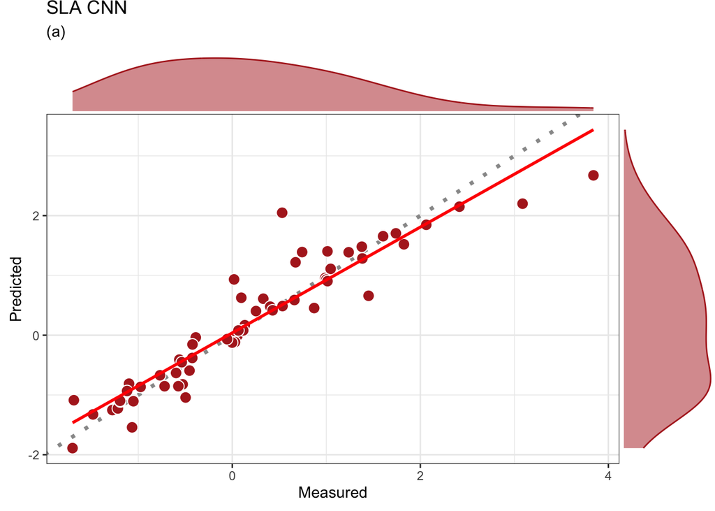

```r
sla.test <- ggMarginal(p1, size = 6, fill = "#B22623", color = "#B22623", alpha = 0.5)


sla.test
```

```r
# Interactive plot
plotly::ggplotly(p1)
```

[interactive chart not shown]

# LDMC

Outliers are removed from the LDMC samples to ensure that only valid observations are included in the analysis.The LDMC values are extracted from the filtered dataset for further analysis. The distribution of the LDMC values is examined using QQ plots and histograms. A QQ plot is generated to assess the normality of the LDMC variable, with a reference line added for visual comparison. A histogram is also created to visualize the distribution of LDMC values, providing insight into the data’s characteristics. The samples were split into train and test set (0.7-0.3) by using a PCA of the spectra

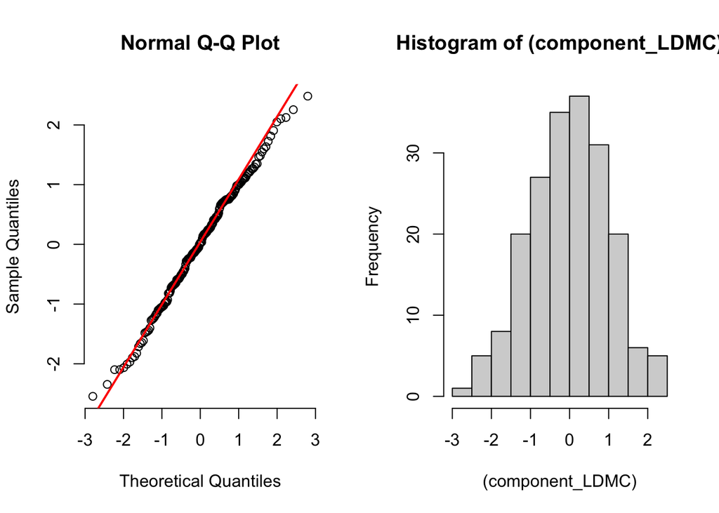

```r
##############
#### LDMC ####
##############

# Removing outlayer from the samples
plantspec.data[which(is.na(plantspec.data$LDMC)),]
input <- as.matrix(plantspec.spectra[, -1])
input <- input[-which(is.na(plantspec.data$LDMC)),]
plantspec.data.ldmc <- plantspec.data[!is.na(plantspec.data$LDMC),]

# Studying the distribution of the values for LDMC
component_LDMC <- plantspec.data.ldmc$LDMC
component_LDMC <- scale(component_LDMC)
par(mfcol = c(1, 2))
qqnorm((component_LDMC), pch = 1, frame = FALSE) # Checking normality of the variable
qqline((component_LDMC), col = "red", lwd = 2)
hist((component_LDMC)) # Checking distribution of the variable
```

```r
#### Train-test split ####
set.seed(0)
training_set <- !(subdivideDataset(spectra = input,
                                   component = component_LDMC,
                                   method = "PCAKS", p = 0.3,
                                   type = "validation"))
```

### Feature Engineering for LDMC

```r
# Standard Norval Variate (SNV)

input <- data.frame(input)
SNV<-function(spectra){
  spectra<-as.matrix(spectra)
  spectrat<-t(spectra)
  spectrat_snv<-scale(spectrat,center=TRUE,scale=TRUE)
  spectra_snv<-t(spectrat_snv)
  return(spectra_snv)}


trans1 <- data.frame(SNV(input))


input <- cbind(trans1)

# Test and train split
x.train <- data.frame(input[training_set, ])
x.test <- data.frame(input[!training_set, ])
y.train <- data.frame(component_LDMC[training_set])
y.test <- data.frame(component_LDMC[!training_set])
```

### CNN for LDMC

```r
#### Convolutional neural network (CNN) ####

set.seed(0)

model.ldmc <- keras_model_sequential(input_shape = c(NULL, 2151, 1)) %>%
  layer_conv_1d(filter = 2, kernel_size = 2, padding="same", kernel_initializer=initializer_glorot_uniform(seed=0)) %>%
  layer_batch_normalization() %>%
  layer_max_pooling_1d(pool_size = 2) %>%
  layer_flatten() %>%
  layer_dense(64, kernel_initializer=initializer_glorot_uniform(seed=0)) %>%
  layer_dense(16, kernel_initializer=initializer_glorot_uniform(seed=0)) %>%
  layer_dense(4, kernel_initializer=initializer_glorot_uniform(seed=0)) %>%
  layer_dense(1, kernel_initializer=initializer_glorot_uniform(seed=0))

model.ldmc %>% compile(
  optimizer = "adam",
  loss = "mean_squared_error")

early_stopping <- callback_early_stopping(
  monitor = "val_loss",  # Monitor validation loss
  patience = 500,          # Stop if no improvement for
  restore_best_weights = TRUE  # Restore weights from the best epoch
)

start_time_ldmc_cnn <- Sys.time()

history <- model.ldmc %>% fit(as.matrix(x.train), as.matrix(y.train),
                              epochs = 7000,
                              verbose = 1,
                              validation_split = 0.2,
                              shuffle = FALSE,
                              callbacks = list(early_stopping)
                              )
end_time_ldmc_cnn <- Sys.time()

p_LDMC <- plot(history, method = "ggplot2")

# Training time
time_ldmc_cnn <- end_time_ldmc_cnn - start_time_ldmc_cnn
```

### Training Model LDMC

```r
# Interactive plots
plotly::ggplotly(p_LDMC)
```

[interactive chart not shown]

### Predictive Ability of CNN for LDMC

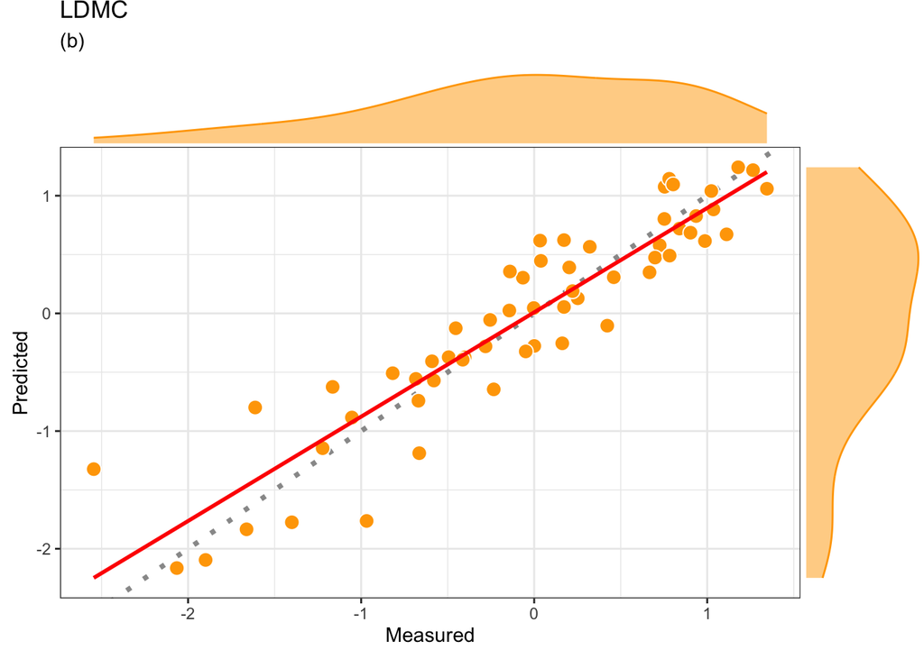

```r
#### Predictive ability of the CNN ####

prediction.test <- predict(model.ldmc, as.matrix(x.test))

# R^2
R2_test.ldmc <- cor(prediction.test, as.matrix(y.test))^2; R2_test.ldmc

# RMSE
prediction.test <- as.numeric(prediction.test)
y.test <- as.numeric(y.test[[1]])
rmse_ldmc <- sqrt(mean((prediction.test - y.test)^2))

# ggplot
data.plot <- data.frame(cbind(prediction.test, as.matrix(y.test)))
names(data.plot) <- c("Predicted", "Measured")
data.plot$Predicted <- as.numeric(data.plot$Predicted)
data.plot$Measured <- as.numeric(data.plot$Measured)
p2 <- ggplot(data = data.plot, aes(y = Predicted, x = Measured)) +
  geom_abline(intercept = 0, slope = 1, linetype = "dotted", color = "grey60", size = 1.3) +
  geom_point(size = 3.5, shape = 21, color = "white", fill = "#ffa600") +
  geom_smooth(method = "lm", col = "red", se = FALSE) +
  theme_bw() +
  labs(title = "LDMC", subtitle = "(b)") + xlab("Measured") + ylab("Predicted")
  theme(plot.title=element_text(hjust=0.5, size = 20))

ldmc.test <- ggMarginal(p2, size = 6, fill = "#ffa600", color = "#ffa600", alpha = 0.5)

ldmc.test
```

```r
# Interactive plots
plotly::ggplotly(p2)
```

[interactive chart not shown]

# Carbon:Nitrogen

Preparing the data for C:N and spltting it for training and testing

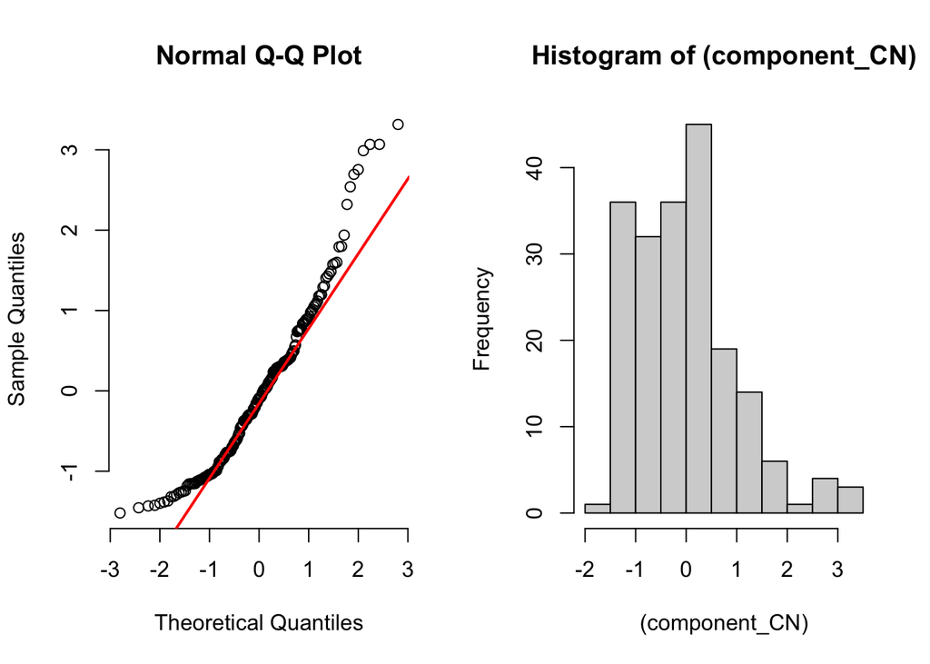

```r
# Removing outlayer from the samples
plantspec.data[which(is.na(plantspec.data$CN)),]
input <- as.matrix(plantspec.spectra[, -1])
input <- input[-which(is.na(plantspec.data$CN)),]
plantspec.data.cn <- plantspec.data[!is.na(plantspec.data$CN),]

# Studying the distribution of the values for CN
component_CN <- plantspec.data.cn$CN
component_CN <- scale(component_CN)
par(mfcol = c(1, 2))
qqnorm((component_CN), pch = 1, frame = FALSE) # Checking normality of the variable
qqline((component_CN), col = "red", lwd = 2)
hist((component_CN)) # Checking distribution of the variable
```

```r
#### Train-test split ####

set.seed(0)
training_set <- !(subdivideDataset(spectra = input,
                                   component = component_CN,
                                   method = "PCAKS", p = 0.3,
                                   type = "validation"))
```

### Feature Engineering for C:N

```r
# Standard Norval Variate (SNV)

input <- data.frame(input)
SNV<-function(spectra){
  spectra<-as.matrix(spectra)
  spectrat<-t(spectra)
  spectrat_snv<-scale(spectrat,center=TRUE,scale=TRUE)
  spectra_snv<-t(spectrat_snv)
  return(spectra_snv)}

trans1 <- data.frame(SNV(input))


input <- cbind(trans1)

# Test and train split
x.train <- data.frame(input[training_set, ])
x.test <- data.frame(input[!training_set, ])
y.train <- data.frame(component_CN[training_set])
y.test <- data.frame(component_CN[!training_set])
```

### CNN for C:N

```r
#### Convolutional neural network (CNN) ####

model.cn <- keras_model_sequential(input_shape = c(NULL, 2151, 1)) %>%
  layer_conv_1d(filter = 1, kernel_size = 25, padding="same", kernel_initializer=initializer_glorot_uniform(seed=0)) %>%
  layer_batch_normalization() %>%
  layer_max_pooling_1d(pool_size = 2) %>%
  layer_flatten() %>%
  layer_dense(64, kernel_initializer=initializer_glorot_uniform(seed=0)) %>%
  layer_dense(16, kernel_initializer=initializer_glorot_uniform(seed=0)) %>%
  layer_dense(4, kernel_initializer=initializer_glorot_uniform(seed=0)) %>%
  layer_dense(1, kernel_initializer=initializer_glorot_uniform(seed=0))


model.cn %>% compile(
  optimizer = "adam",
  loss = "mean_squared_error")

early_stopping <- callback_early_stopping(
  monitor = "val_loss",  # Monitor validation loss
  patience = 500,          # Stop if no improvement for 3 epochs
  restore_best_weights = TRUE  # Restore weights from the best epoch
)

set.seed(0)
start_time_cn_cnn <- Sys.time()
history <- model.cn %>% fit(as.matrix(x.train), as.matrix(y.train),
                            epochs = 1000,
                            verbose = 1,
                            validation_split = 0.2,
                            shuffle = FALSE,
                            callbacks = list(early_stopping))

end_time_cn_cnn <- Sys.time()

p_CN <- plot(history, method = "ggplot2")

# Training time
time_cn_cnn <- end_time_cn_cnn - start_time_cn_cnn
```

### Training Model C:N

```r
# Interactive plots
plotly::ggplotly(p_CN)
```

[interactive chart not shown]

### Predictive Ability of CNN for C:N

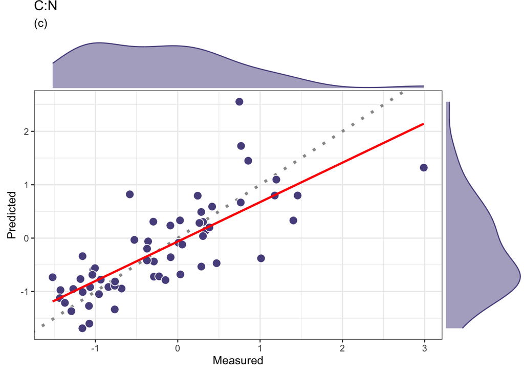

```r
#### Predictive ability of the CNN ####

prediction.test <- predict(model.cn, as.matrix(x.test))

# R2
R2_test.cn <- cor(prediction.test, as.matrix(y.test))^2; R2_test.cn

# RMSE
prediction.test <- as.numeric(prediction.test)
y.test <- as.numeric(y.test[[1]])
rmse_cn <- sqrt(mean((prediction.test - y.test)^2))


# ggplot
data.plot <- data.frame(cbind(prediction.test, as.matrix(y.test)))
names(data.plot) <- c("Predicted", "Measured")
data.plot$Predicted <- as.numeric(data.plot$Predicted)
data.plot$Measured <- as.numeric(data.plot$Measured)
p3 <- ggplot(data = data.plot, aes(y = Predicted, x = Measured)) +
  geom_abline(intercept = 0, slope = 1, linetype = "dotted", color = "grey60", size = 1.3) +
  geom_point(size = 3.5, shape = 21, color = "white", fill = "#58508d") +
  geom_smooth(method = "lm", col = "red", se = FALSE) +
  theme_bw() +
  labs(title = "C:N", subtitle = "(c)") + xlab("Measured") + ylab("Predicted")
  theme(plot.title=element_text(hjust=0.5, size = 20))

cn.test <- ggMarginal(p3, size = 5, fill = "#58508d", color = "#58508d", alpha = 0.5)


cn.test
```

```r
# Interactive plots
plotly::ggplotly(p3)
```

[interactive chart not shown]

# Carbon

Outliers are removed, the distribution of Carbon(C) values is analyzed, and the data is split into training and test sets using PCA for validation.

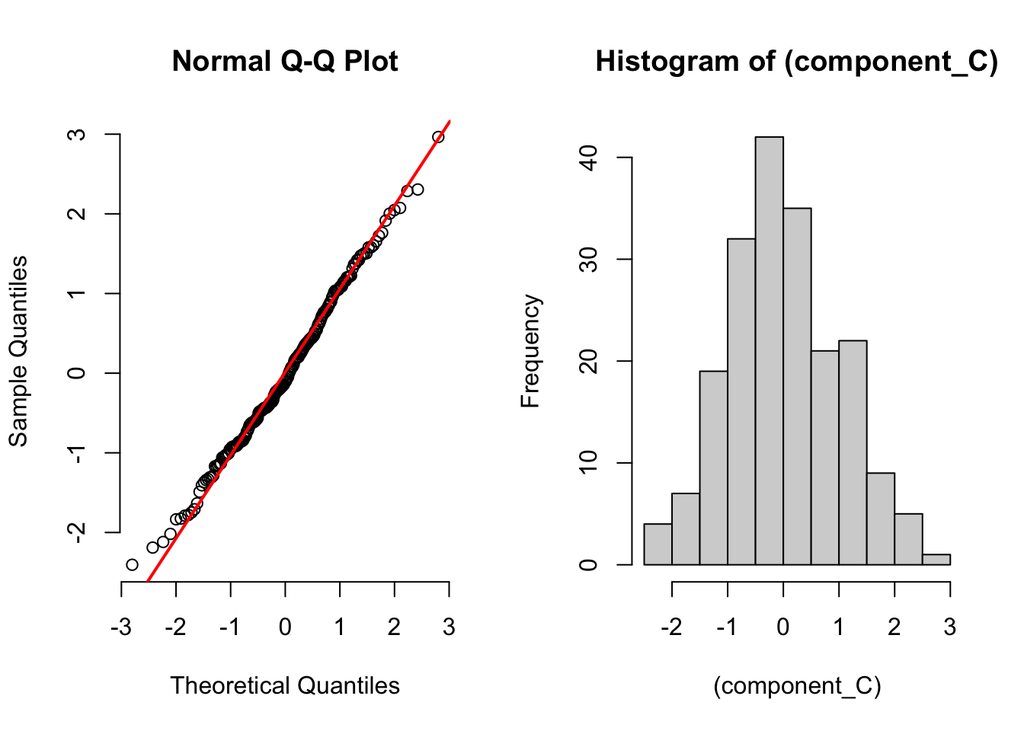

```r
###########
#### C ####
###########

# Removing outlayer from the samples
plantspec.data[which(is.na(plantspec.data$C)),]
input <- as.matrix(plantspec.spectra[, -1])
input <- input[-which(is.na(plantspec.data$C)),]
plantspec.data.c <- plantspec.data[!is.na(plantspec.data$C),]

# Studying the distribution of the values for CN
component_C <- plantspec.data.c$C
component_C <- scale(component_C)
par(mfcol = c(1, 2))
qqnorm((component_C), pch = 1, frame = FALSE) # Checking normality of the variable
qqline((component_C), col = "red", lwd = 2)
hist((component_C)) # Checking distribution of the variable
```

```r
#### Train-test split ####
# We split our samples into train and test set (0.7-0.3) by using
# a PCA of the spectra
set.seed(0)
training_set <- !(subdivideDataset(spectra = input,
                                   component = component_C,
                                   method = "PCAKS", p = 0.3,
                                   type = "validation"))
```

### Feature Engineering for Carbon

```r
#### Feature Engineering ####

# Standard Norval Variate (SNV)


input <- data.frame(input)
SNV<-function(spectra){
  spectra<-as.matrix(spectra)
  spectrat<-t(spectra)
  spectrat_snv<-scale(spectrat,center=TRUE,scale=TRUE)
  spectra_snv<-t(spectrat_snv)
  return(spectra_snv)}

input <- data.frame(input)

trans1 <- data.frame(SNV(input))

input <- cbind(trans1)

# Test and train split
x.train <- data.frame(input[training_set, ])
x.test <- data.frame(input[!training_set, ])
y.train <- data.frame(component_C[training_set])
y.test <- data.frame(component_C[!training_set])
```

### CNN for Carbon

```r
#### Convolutional neural network (CNN) ####


model.c <- keras_model_sequential(input_shape = c(NULL, 2151, 1)) %>%
  layer_conv_1d(filter = 2, kernel_size = 50, padding="same", kernel_initializer=initializer_glorot_uniform(seed=0)) %>%
  layer_batch_normalization() %>%
  layer_max_pooling_1d(pool_size = 2) %>%
  layer_dropout(0) %>%
  layer_flatten() %>%
  layer_dense(64, kernel_initializer=initializer_glorot_uniform(seed=0)) %>%
  layer_dense(16, kernel_initializer=initializer_glorot_uniform(seed=0)) %>%
  layer_dense(4, kernel_initializer=initializer_glorot_uniform(seed=0)) %>%
  layer_dense(1, kernel_initializer=initializer_glorot_uniform(seed=0))


model.c %>% compile(
  optimizer = "adam",
  loss = "mean_squared_error")

early_stopping <- callback_early_stopping(
  monitor = "val_loss",  # Monitor validation loss
  patience = 500,          # Stop if no improvement for 3 epochs
  restore_best_weights = TRUE  # Restore weights from the best epoch
)


set.seed(0)
start_time_c_cnn <- Sys.time()
history <- model.c %>% fit(as.matrix(x.train), as.matrix(y.train),
                            epochs = 1000,
                            verbose = 1,
                            validation_split = 0.2,
                            shuffle = FALSE,
                           callbacks = list(early_stopping))
end_time_c_cnn <- Sys.time()

p_C <- plot(history, method = "ggplot2")

# Training time
time_c_cnn <- end_time_c_cnn - start_time_c_cnn
```

### Training Model Carbon

```r
# Interactive plots
plotly::ggplotly(p_C)
```

[interactive chart not shown]

### Predictive Ability of CNN for Carbon

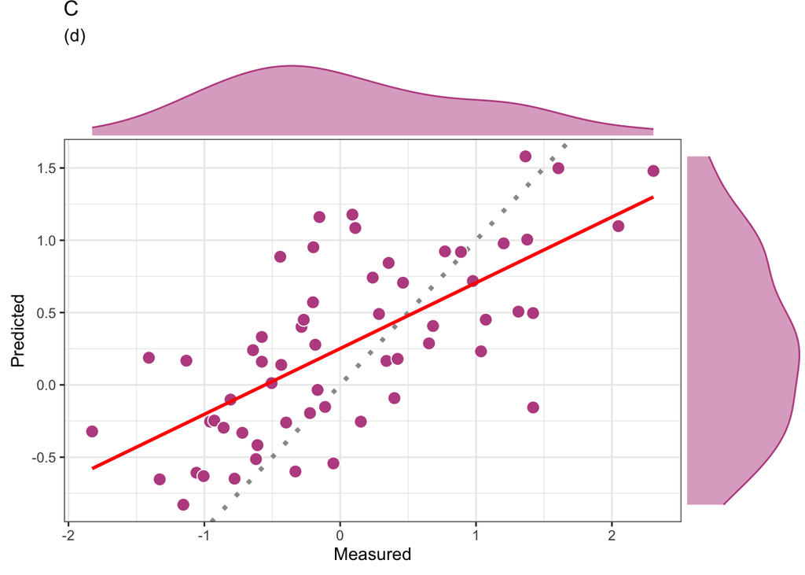

```r
#### Predictive ability of the CNN ####

prediction.test <- predict(model.c, as.matrix(x.test))

# R^2
R2_test.c <- cor(prediction.test, as.matrix(y.test))^2; R2_test.c

# RMSE
prediction.test <- as.numeric(prediction.test)
y.test <- as.numeric(y.test[[1]])
rmse_c <- sqrt(mean((prediction.test - y.test)^2))
rmse_c

# ggplot
data.plot <- data.frame(cbind(prediction.test, as.matrix(y.test)))
names(data.plot) <- c("Predicted", "Measured")
data.plot$Predicted <- as.numeric(data.plot$Predicted)
data.plot$Measured <- as.numeric(data.plot$Measured)
p4 <- ggplot(data = data.plot, aes(y = Predicted, x = Measured)) +
  geom_abline(intercept = 0, slope = 1, linetype = "dotted", color = "grey60", size = 1.3) +
  geom_point(size = 3.5, shape = 21, color = "white", fill = "#bc5090") +
  geom_smooth(method = "lm", col = "red", se = FALSE) +
  theme_bw() +
  labs(title = "C", subtitle = "(d)") + xlab("Measured") + ylab("Predicted")
  theme(plot.title=element_text(hjust=0.5, size = 20))

c.test <- ggMarginal(p4, size = 5, fill = "#bc5090", color = "#bc5090", alpha = 0.5)



c.test
```

```r
# Interactive plot
plotly::ggplotly(p4)
```

[interactive chart not shown]

# Phosphorous

Due to the smaller sample size for phosphorous (P), we additionally used data from Pross et al. (2023) collected in the Kreinitz experiment (Germany) to train a CNN. As our samples only contain samples for deciduous species, we only used the available data for deciduous species.

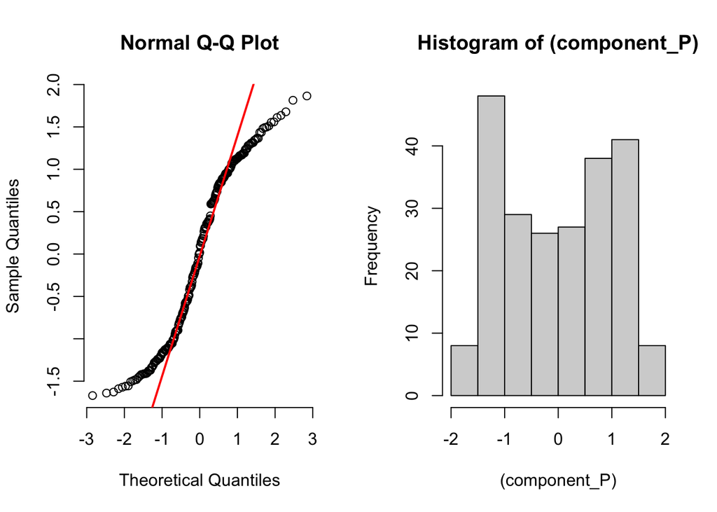

```r
###########
#### P ####
###########

#### Loading Kreinitz data ####

plantspec.spectra2 <- read_excel("/Users/methungeorge/Desktop/IPB/pablo/dataset_20231010.xlsx", sheet = "Kreinitz set spectra") # Spectral Kreinitz set
plantspec.data2 <- read_excel("/Users/methungeorge/Desktop/IPB/pablo/dataset_20231010.xlsx", sheet = "Kreinitz set traits") # Traits Kreinitz set

cbind(plantspec.spectra2$Spectral.file.name, plantspec.data2$Level_ID) # Checking correlation between both sets

# Removing outlayer from the samples
plantspec.data[which(is.na(plantspec.data$P)),]
input <- as.matrix(plantspec.spectra[, -1])
input <- input[-which(is.na(plantspec.data$P)),]
plantspec.data.p <- plantspec.data[!is.na(plantspec.data$P),]
input <- input[-which(plantspec.data.p$Tree == "75_So2"),]
plantspec.data.p <- subset(plantspec.data.p, Tree != "75_So2")
input <- input[-which(plantspec.data.p$Tree == "16_Be3"),]
plantspec.data.p <- subset(plantspec.data.p, Tree != "16_Be3")
input <- input[-which(plantspec.data.p$Tree == "71_Fa3"),]
plantspec.data.p <- subset(plantspec.data.p, Tree != "71_Fa3")


plantspec.data[which(is.na(plantspec.data2$P)),]

input2 <- as.matrix(plantspec.spectra2[, -1])
input2 <- input2[-which(plantspec.data2$Level_ID == "B16_Li17_3"),]
plantspec.data2 <- subset(plantspec.data2, Level_ID != "B16_Li17_3")
input2 <- input2[-which(plantspec.data2$Level_ID == "B41_Es11_3"),]
plantspec.data2 <- subset(plantspec.data2, Level_ID != "B41_Es11_3")

# Studying the distribution of the values for P
component_P <- c(plantspec.data.p$P, plantspec.data2$P)
component_P <- scale(component_P)
par(mfcol = c(1, 2))
qqnorm((component_P), pch = 1, frame = FALSE) # Checking normality of the variable
qqline((component_P), col = "red", lwd = 2)
hist((component_P)) # Checking distribution of the variable
```

```r
#### Train-test split ####
# We split our samples into train and test set (0.7-0.3) by using
# a PCA of the spectra
set.seed(0)
training_set <- !(subdivideDataset(spectra = input,
                                   component = component_P,
                                   method = "PCAKS", p = 0.3,
                                   type = "validation"))
```

### Feature Engineering for Phosphorous

```r
#### Feature Engineering ####

# Standard Norval Variate (SNV)


input <- data.frame(rbind(input, input2))
SNV<-function(spectra){
  spectra<-as.matrix(spectra)
  spectrat<-t(spectra)
  spectrat_snv<-scale(spectrat,center=TRUE,scale=TRUE)
  spectra_snv<-t(spectrat_snv)
  return(spectra_snv)}

trans1 <- data.frame(SNV(input))

input <- cbind(trans1)

# Test and train split
x.train <- data.frame(input[training_set, ])
x.test <- data.frame(input[!training_set, ])
y.train <- data.frame(component_P[training_set])
y.test <- data.frame(component_P[!training_set])
```

### CNN for Phosphorous

```r
#### Convolutional neural network (CNN) ####


model.p <- keras_model_sequential(input_shape = c(NULL, 2151, 1)) %>%
  layer_conv_1d(filter = 1, kernel_size = 100,  padding="same", kernel_initializer=initializer_glorot_uniform(seed=0)) %>%
  layer_batch_normalization() %>%
  layer_max_pooling_1d(pool_size = 2) %>%
  layer_flatten() %>%
  layer_dense(64, kernel_initializer=initializer_glorot_uniform(seed=0)) %>%
  layer_dense(16, kernel_initializer=initializer_glorot_uniform(seed=0)) %>%
  layer_dense(4, kernel_initializer=initializer_glorot_uniform(seed=0)) %>%
  layer_dense(1, kernel_initializer=initializer_glorot_uniform(seed=0))

model.p %>% compile(
  optimizer = "adam",
  loss = "mean_squared_error")

set.seed(0)
start_time_p_cnn <- Sys.time()
history <- model.p %>% fit(as.matrix(x.train), as.matrix(y.train),
                           epochs = 100,
                           verbose = 1,
                           validation_split = 0.2,
                           shuffle = FALSE)

end_time_p_cnn <- Sys.time()

p_P <- plot(history, method = "ggplot2")

# Training time
time_cnn_p <- end_time_p_cnn - start_time_p_cnn
```

### Training Model Phosphorous

```r
# Interactive plots
plotly::ggplotly(p_P)
```

[interactive chart not shown]

### Predictive Ability of CNN for Phosphorous

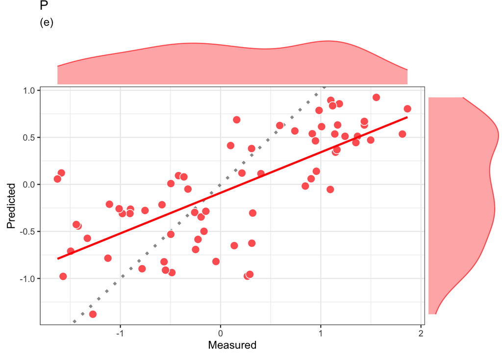

```r
#### Predictive ability of the CNN ####

prediction.test <- predict(model.p, as.matrix(x.test))

# R^2
R2_test.p <- cor(prediction.test, as.matrix(y.test))^2; R2_test.p

# RMSE
prediction.test <- as.numeric(prediction.test)
y.test <- as.numeric(y.test[[1]])
rmse_p <- sqrt(mean((prediction.test - y.test)^2))
rmse_p



# ggplot
data.plot <- data.frame(cbind(prediction.test, as.matrix(y.test)))
names(data.plot) <- c("Predicted", "Measured")
data.plot$Predicted <- as.numeric(data.plot$Predicted)
data.plot$Measured <- as.numeric(data.plot$Measured)
p5 <- ggplot(data = data.plot, aes(y = Predicted, x = Measured)) +
  geom_abline(intercept = 0, slope = 1, linetype = "dotted", color = "grey60", size = 1.3) +
  geom_point(size = 3.5, shape = 21, color = "white", fill = "#ff6361") +
  geom_smooth(method = "lm", col = "red", se = FALSE) +
  theme_bw() +
  labs(title = "P", subtitle = "(e)") + xlab("Measured") + ylab("Predicted")
  theme(plot.title=element_text(hjust=0.5, size = 20))

p.test <- ggMarginal(p5, size = 5, fill = "#ff6361", color = "#ff6361", alpha = 0.5)



p.test
```

```r
# Interactive plot
plotly::ggplotly(p5)
```

[interactive chart not shown]

# Extrapolation of CNN

```r
# Study on SLA trait
# Data processing
# Removing outlayer from the samples
plantspec.data[which(is.na(plantspec.data$SLA)),]
input <- as.matrix(plantspec.spectra[, -1])
input <- input[-which(is.na(plantspec.data$SLA)),]
plantspec.data.sla <- plantspec.data[!is.na(plantspec.data$SLA),]
input <- input[-which(plantspec.data$Tree == "70_Ti3"),]
plantspec.data.sla <- subset(plantspec.data.sla, Tree != "70_Ti3")

# Studying the distribution of the values for SLA
component_SLA <- plantspec.data.sla$SLA

#we manually select the extreme values from both sides
X <- input
Y <- plantspec.data.sla$SLA

# Scale the input (spectral data) and SLA values for better model
X_scaled <- scale(X)
Y_scaled <- scale(Y)

set.seed(0)
#Highest 30% of Values
cutoff <- quantile(component_SLA, 0.7, na.rm = TRUE)
#index for test set
test_set_index_h <- which(component_SLA >= cutoff)
#index for trainig set
training_set_index_h <- which(component_SLA < cutoff)
#split the scaled data accordingly
X_train_e_h <- X_scaled[training_set_index_h, ]
Y_train_e_h <- Y_scaled[training_set_index_h]
X_test_e_h <- X_scaled[test_set_index_h, ]
Y_test_e_h <- Y_scaled[test_set_index_h]

#### Convolutional neural network (CNN) ####


model.sla <- keras_model_sequential(input_shape = c(NULL, 2151, 1)) %>%
  layer_conv_1d(filter = 2, kernel_size = 50, padding="same",
                kernel_initializer=initializer_glorot_uniform(seed=0)) %>%
  layer_batch_normalization() %>%
  layer_max_pooling_1d(pool_size = 2) %>%
  layer_flatten() %>%
  layer_dense(128, kernel_initializer=initializer_glorot_uniform(seed=0)) %>%
  layer_dense(32, kernel_initializer=initializer_glorot_uniform(seed=0)) %>%
  layer_dense(8, kernel_initializer=initializer_glorot_uniform(seed=0)) %>%
  layer_dense(1, kernel_initializer=initializer_glorot_uniform(seed=0))

model.sla %>% compile(
  optimizer = "adam",
  loss = "mean_squared_error")

# Define early stopping callback
early_stopping <- callback_early_stopping(
  monitor = "val_loss",  # Monitor validation loss
  patience = 500,          # Stop if no improvement for 500 epochs
  restore_best_weights = TRUE  # Restore weights from the best epoch
)

start_time_sla_cnn <- Sys.time()
history <- model.sla %>% fit(x=as.matrix(X_train_e_h), y=as.matrix(Y_train_e_h),
                         epochs = 5000,
                         verbose = 1,
                         validation_split = 0.2,
                         shuffle = FALSE,
                         callbacks = list(early_stopping)
                         )
end_time_sla_cnn <- Sys.time()


# Training time
time_cnn_sla_h <- end_time_sla_cnn - start_time_sla_cnn


#### Predictive ability of the CNN ####

prediction.test_e_h <- predict(model.sla, as.matrix(X_test_e_h))

# R^2
R2_test.sla_e_h <- cor(prediction.test_e_h, as.matrix(Y_test_e_h))^2; R2_test.sla_e_h

# RMSE
prediction.test_e_h <- as.numeric(prediction.test_e_h)
y.test_e_h <- as.numeric(Y_test_e_h[[1]])
rmse_sla_e_h <- sqrt(mean((prediction.test_e_h - y.test_e_h)^2))
rmse_sla_e_h

# ggplot
data.plot <- data.frame(cbind(prediction.test_e_h, as.matrix(Y_test_e_h)))
names(data.plot) <- c("Predicted", "Measured")
data.plot$Predicted <- as.numeric(data.plot$Predicted)
data.plot$Measured <- as.numeric(data.plot$Measured)
p1_e_h <- ggplot(data = data.plot, aes(y = Predicted, x = Measured)) +
  geom_abline(intercept = 0, slope = 1, linetype = "dotted", color = "grey60", size = 1.3) +
  geom_point(size = 3.5, shape = 21, color = "white", fill = "#B22623") +
  geom_smooth(method = "lm", col = "red", se = FALSE) +
  theme_bw() +
  labs(title = "SLA CNN  Extrapolation (H30%)", subtitle = "(a)") + xlab("Measured") + ylab("Predicted")
  theme(plot.title=element_text(hjust=0.5, size = 20))

  sla.test_e_h <- ggMarginal(p1_e_h, size = 6, fill = "#B22623", color = "#B22623", alpha = 0.5)
```

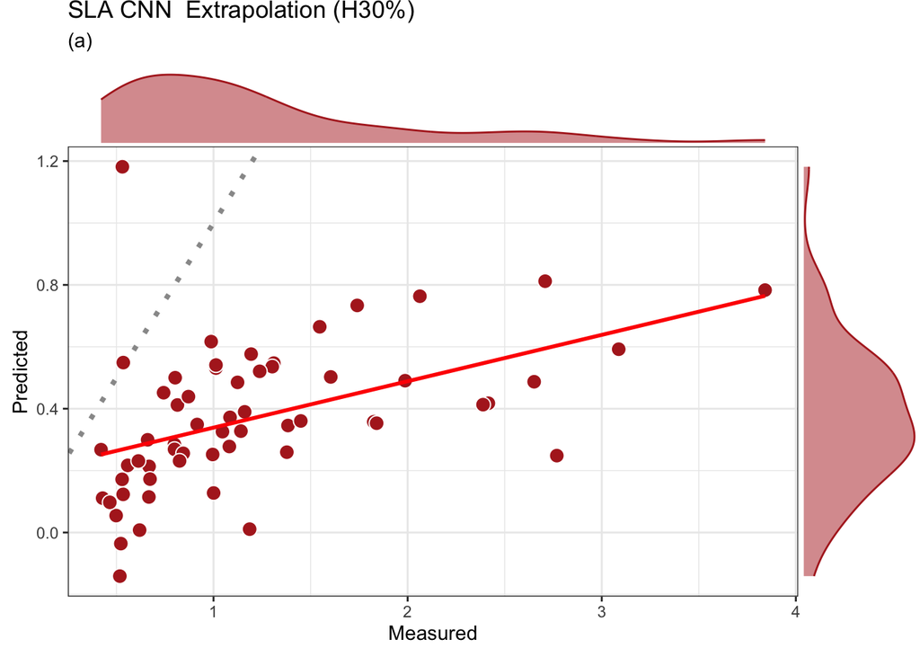

```r
# Extrapolation on upper data range plot
sla.test_e_h
```

# Extrapolation on Lowest 30% of values

```r
set.seed(0)

# Define the cutoff
cutoff_low <- quantile(component_SLA, 0.3, na.rm = TRUE)
#index for test set
test_set_index_l <- which(component_SLA <= cutoff_low)
#index for trainig set
training_set_index_l <- which(component_SLA > cutoff_low)
#split the scaled data accordingly
X_train_e_l <- X_scaled[training_set_index_l, ]
Y_train_e_l <- Y_scaled[training_set_index_l]
X_test_e_l <- X_scaled[test_set_index_l, ]
Y_test_e_l <- Y_scaled[test_set_index_l]


#### Convolutional neural network (CNN) ####


model.sla <- keras_model_sequential(input_shape = c(NULL, 2151, 1)) %>%
  layer_conv_1d(filter = 2, kernel_size = 50, padding="same",
                kernel_initializer=initializer_glorot_uniform(seed=0)) %>%
  layer_batch_normalization() %>%
  layer_max_pooling_1d(pool_size = 2) %>%
  layer_flatten() %>%
  layer_dense(128, kernel_initializer=initializer_glorot_uniform(seed=0)) %>%
  layer_dense(32, kernel_initializer=initializer_glorot_uniform(seed=0)) %>%
  layer_dense(8, kernel_initializer=initializer_glorot_uniform(seed=0)) %>%
  layer_dense(1, kernel_initializer=initializer_glorot_uniform(seed=0))

model.sla %>% compile(
  optimizer = "adam",
  loss = "mean_squared_error")

# Define early stopping callback
early_stopping <- callback_early_stopping(
  monitor = "val_loss",  # Monitor validation loss
  patience = 500,          # Stop if no improvement for 500 epochs
  restore_best_weights = TRUE  # Restore weights from the best epoch
)

start_time_sla_cnn <- Sys.time()
history <- model.sla %>% fit(x=as.matrix(X_train_e_l), y=as.matrix(Y_train_e_l),
                         epochs = 5000,
                         verbose = 1,
                         validation_split = 0.2,
                         shuffle = FALSE,
                         callbacks = list(early_stopping)
                         )
end_time_sla_cnn <- Sys.time()


# Training time
time_cnn_sla_l <- end_time_sla_cnn - start_time_sla_cnn


#### Predictive ability of the CNN ####

prediction.test_e_l <- predict(model.sla, as.matrix(X_test_e_l))

# R^2
R2_test.sla_e_l <- cor(prediction.test_e_l, as.matrix(Y_test_e_l))^2; R2_test.sla_e_l

# RMSE
prediction.test_e_l <- as.numeric(prediction.test_e_l)
y.test_e_l <- as.numeric(Y_test_e_l[[1]])
rmse_sla_e_l <- sqrt(mean((prediction.test_e_l - y.test_e_l)^2))
rmse_sla_e_l

# ggplot
data.plot <- data.frame(cbind(prediction.test_e_l, as.matrix(Y_test_e_l)))
names(data.plot) <- c("Predicted", "Measured")
data.plot$Predicted <- as.numeric(data.plot$Predicted)
data.plot$Measured <- as.numeric(data.plot$Measured)

p1_e_l <- ggplot(data = data.plot, aes(y = Predicted, x = Measured)) +
  geom_abline(intercept = 0, slope = 1, linetype = "dotted", color = "grey60", size = 1.3) +
  geom_point(size = 3.5, shape = 21, color = "white", fill = "#B22623") +
  geom_smooth(method = "lm", col = "red", se = FALSE) +
  theme_bw() +
  labs(title = "SLA CNN  Extrapolation (L30%)", subtitle = "(a)") + xlab("Measured") + ylab("Predicted")
  theme(plot.title=element_text(hjust=0.5, size = 20))

  sla.test_e_l <- ggMarginal(p1_e_l, size = 6, fill = "#B22623", color = "#B22623", alpha = 0.5)
```

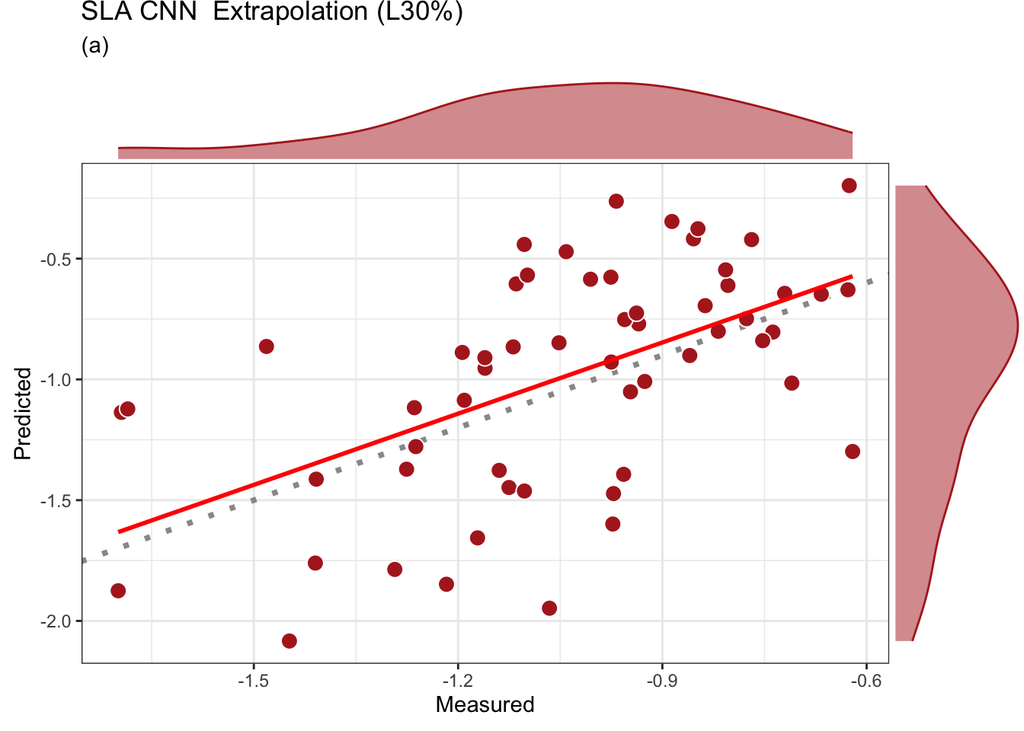

```r
# Extrapolation on lower data range plot
sla.test_e_l
```

# Correlation Between Measured Traits and CNN Predictions

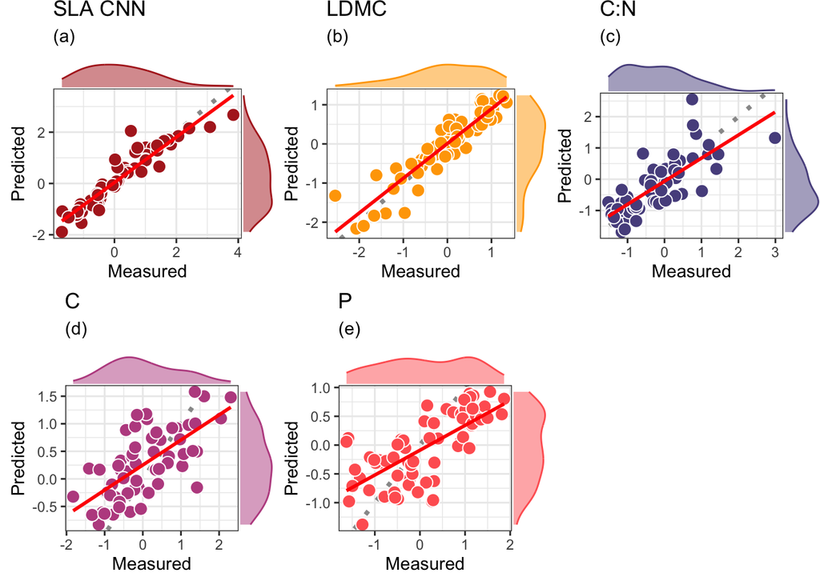

```r
# Plot: Correlations between measured traits and predicted values by CNN
grid.arrange(sla.test, ldmc.test, cn.test, c.test, p.test,
              nrow = 2) # EXPORT AS 9 x 20 inches
```